# Pronosticos_Holt_Winters_demanda_electrico

Sergi

2023-02-27

## APLICATION OF SMOTHING METHODS IN R

```r
library(tidyverse)      # data manipulation and visualization
library(lubridate)      # easily work with dates and times
library(fpp2)           # working with time series data
library(zoo)
```

```r
library(ggplot2)
library(plyr)
library(dplyr)
library(knitr)
library(TTR)
library(hydroGOF)
```

We first import our data

```r
#URL HPi5
#Demanda_electrico_importado<-read.csv("C:\\Users\\llell\\Documents\\MIS\\Second_semester\\Pronosticos_UNAM_HPi5\\pronosticos_UNAM_git\\pronosticos_UNAM_gitHub\\Demanda_electrico_2022_full1.csv", header= TRUE)

#URL HPi3
Demanda_electrico_importado<-read.csv("C:\\Users\\sergi\\OneDrive\\Documentos\\MIS_UNAM\\Segundo_semestre\\Pronosticos_UNAM_HPi3\\pronosticos_UNAM_git\\Demanda_electrico_2022_full1.csv", header= TRUE)
```

We checked the importing has worked

```r
head(Demanda_electrico_importado)
```

```
##       Date Demanded_Gas
## 1 1/1/2005      1819.58
## 2 2/1/2005      1895.33
## 3 3/1/2005      1765.86
## 4 4/1/2005      1642.70
## 5 5/1/2005      1895.54
## 6 6/1/2005      2051.72
```

```r
summary(Demanda_electrico_importado)
```

```
##      Date            Demanded_Gas
##  Length:213         Min.   :1561
##  Class :character   1st Qu.:2600
##  Mode  :character   Median :3016
##                     Mean   :3038
##                     3rd Qu.:3403
##                     Max.   :5168
```

```r
typeof(Demanda_electrico_importado)
```

```
## [1] "list"
```

```r
dim(Demanda_electrico_importado)
```

```
## [1] 213   2
```

We add a new columns in a data type of data by transforming our ‘original’ Date columns into an as.date column

```r
Demanda_electrico_importado$as.date <- as.Date(Demanda_electrico_importado$Date, format = "%m/%d/%Y")
head(Demanda_electrico_importado)
```

```
##       Date Demanded_Gas    as.date
## 1 1/1/2005      1819.58 2005-01-01
## 2 2/1/2005      1895.33 2005-02-01
## 3 3/1/2005      1765.86 2005-03-01
## 4 4/1/2005      1642.70 2005-04-01
## 5 5/1/2005      1895.54 2005-05-01
## 6 6/1/2005      2051.72 2005-06-01
```

```r
tail(Demanda_electrico_importado)
```

```
##         Date Demanded_Gas    as.date
## 208 4/1/2022      3403.44 2022-04-01
## 209 5/1/2022      3350.03 2022-05-01
## 210 6/1/2022      3498.70 2022-06-01
## 211 7/1/2022      3350.97 2022-07-01
## 212 8/1/2022      3506.42 2022-08-01
## 213 9/1/2022      3778.37 2022-09-01
```

```r
typeof(Demanda_electrico_importado)
```

```
## [1] "list"
```

```r
dim(Demanda_electrico_importado)
```

```
## [1] 213   3
```

#### To be able to use HoltWinters Methond in R, our data must be in a ‘time series’ type of data, time series methods come from the forecast library

```r
Demanda_electrico_importado.ts<- ts(Demanda_electrico_importado$Demanded_Gas, frequency = 12, start =c(2005,1), end =c(2022,8))
head(Demanda_electrico_importado.ts)
```

```
##          Jan     Feb     Mar     Apr     May     Jun
## 2005 1819.58 1895.33 1765.86 1642.70 1895.54 2051.72
```

```r
typeof(Demanda_electrico_importado.ts)
```

```
## [1] "double"
```

```r
dim(Demanda_electrico_importado.ts)
```

Then we plot the ‘original demanded gas in electric time series’

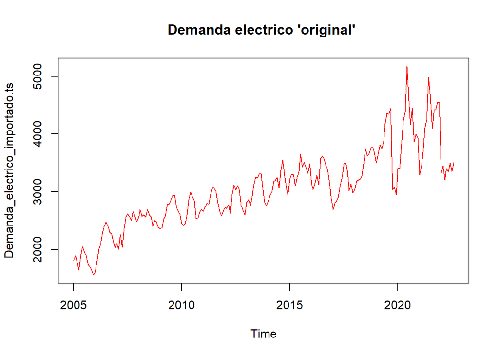

```r
plot(Demanda_electrico_importado.ts, col = "red", main = "Demanda electrico 'original' ")
```

## Methods for Exponential smoothing in time series

The idea behind: Forecast future values using a weighted average of all previous values in the series. Also with the idea that the weight associated with the previous values, decline over time

## Nonseasonal Methods

### Simple Exponential smoothing (SES)

Source https://www.youtube.com/watch?v=Fqge2HDH2Co

FOR SERIRES WITH NO TREND AND NO SEASONALITY

Weights all of the past data with exponentially decreasing weights going into the past. In other words, usually the more recent data has greater weight.

Single exponential smoothing has one parameter ‘alpha’: The controlling smoothing factor for a particular level alpha (a) is the smoothing constant. The value of alpha can be any number between 0 and 1, not inclusive. where the larger values of the predictive model mean it focuses on last observations, and the smaller values focus on history. Learning is fastest at one and slowest at zero values of alpha. Alpha controls the exponential decay influencing rate of past observations.

The next value $\hat{Y}_{t} :$ at time t is estimated as the ‘level of the series at time t-1’:

$$\hat{Y}_{t} = l_{t-1}$$
Where: $\hat{Y}_{t} :$ Forecast for time t $l_{t-1} :$ Level at time t-1

And, the weight of each and every parameter is always determined by alpha value described below:

$$l_{t-1} = \alpha * y_{y} + (1-\alpha
)*l_{t-2}$$

Where: $y_{y} :$ ‘Known’ value at time t $l_{t-2} :$ Level at time t-2 $\alpha :$ Smoothing factor

### Replication of Simple Exponential Smoothing (SES) in R (https://www.geeksforgeeks.org/exponential-smoothing-in-r-programming/)

In R, the prerequisites of this analysis will be installing the required packages. We need to install the following two packages using the install.packages() command from the R console:

fpp2 (with which the forecast package will be automatically loaded) tidyverse

Then we are able to apply the SES method in R

```r
Demanda_electrico_SES <- ses(Demanda_electrico_importado.ts, alpha=0.2)
head(Demanda_electrico_SES)
```

```
## $model
## Simple exponential smoothing
##
## Call:
##  ses(y = Demanda_electrico_importado.ts, alpha = 0.2)
##
##   Smoothing parameters:
##     alpha = 0.2
##
##   Initial states:
##     l = 1838.6144
##
##   sigma:  306.11
##
##      AIC     AICc      BIC
## 3564.539 3564.597 3571.252
##
## $mean
##           Jan      Feb      Mar      Apr      May      Jun Jul Aug      Sep
## 2022                                                               3572.803
## 2023 3572.803 3572.803 3572.803 3572.803 3572.803 3572.803
##           Oct      Nov      Dec
## 2022 3572.803 3572.803 3572.803
## 2023
##
## $level
## [1] 80 95
##
## $x
##          Jan     Feb     Mar     Apr     May     Jun     Jul     Aug     Sep
## 2005 1819.58 1895.33 1765.86 1642.70 1895.54 2051.72 1962.05 1889.66 1739.10
## 2006 1610.45 1806.33 2006.88 2108.31 2298.90 2398.88 2480.62 2413.08 2298.49
## 2007 2108.85 2006.81 2259.02 2036.62 2361.78 2567.22 2618.43 2579.35 2506.83
## 2008 2548.33 2694.39 2575.71 2600.26 2562.91 2689.60 2598.57 2561.87 2404.84
## 2009 2364.05 2377.22 2536.70 2585.33 2782.32 2786.68 2866.00 2939.05 2943.11
## 2010 2452.18 2415.37 2460.19 2643.90 2864.36 2991.73 2917.25 2846.52 2540.74
## 2011 2662.78 2741.30 2802.85 2787.80 2964.66 3073.95 3065.73 3016.10 2822.19
## 2012 2732.35 2712.34 2772.88 2619.31 2955.93 3118.81 3035.23 3107.21 3037.41
## 2013 2823.51 2864.93 2761.36 2893.01 3112.88 3258.90 3238.75 3315.44 3305.59
## 2014 2837.06 2933.25 2997.46 3181.93 3201.21 3248.36 3064.23 3370.22 3547.07
```

[output cut: 38 more lines]

```
## May 2023 4023.516 4262.110
## Jun 2023 4030.294 4272.476
##
## $lower
##               80%      95%
## Sep 2022 3180.507 2972.838
## Oct 2022 3172.738 2960.957
## Nov 2022 3165.117 2949.301
## Dec 2022 3157.636 2937.860
## Jan 2023 3150.287 2926.621
## Feb 2023 3143.064 2915.575
## Mar 2023 3135.961 2904.711
## Apr 2023 3128.971 2894.020
## May 2023 3122.089 2883.496
## Jun 2023 3115.311 2873.130
```

```r
tail(Demanda_electrico_SES)
```

```
## $upper
##               80%      95%
## Sep 2022 3965.098 4172.767
## Oct 2022 3972.867 4184.649
## Nov 2022 3980.488 4196.304
## Dec 2022 3987.970 4207.746
## Jan 2023 3995.318 4218.984
## Feb 2023 4002.541 4230.031
## Mar 2023 4009.645 4240.895
## Apr 2023 4016.635 4251.585
## May 2023 4023.516 4262.110
## Jun 2023 4030.294 4272.476
##
## $lower
##               80%      95%
## Sep 2022 3180.507 2972.838
## Oct 2022 3172.738 2960.957
## Nov 2022 3165.117 2949.301
## Dec 2022 3157.636 2937.860
## Jan 2023 3150.287 2926.621
## Feb 2023 3143.064 2915.575
## Mar 2023 3135.961 2904.711
## Apr 2023 3128.971 2894.020
## May 2023 3122.089 2883.496
## Jun 2023 3115.311 2873.130
##
## $fitted
##           Jan      Feb      Mar      Apr      May      Jun      Jul      Aug
## 2005 1838.614 1834.807 1846.912 1830.702 1793.101 1813.589 1861.215 1881.382
## 2006 1742.482 1716.075 1734.126 1788.677 1852.604 1941.863 2033.266 2122.737
## 2007 2166.385 2154.878 2125.265 2152.016 2128.937 2175.505 2253.848 2326.765
## 2008 2480.914 2494.397 2534.396 2542.659 2554.179 2555.925 2582.660 2585.842
## 2009 2497.989 2471.201 2452.405 2469.264 2492.477 2550.446 2597.693 2651.354
## 2010 2712.532 2660.462 2611.443 2581.193 2593.734 2647.859 2716.633 2756.757
## 2011 2686.173 2681.494 2693.455 2715.334 2729.827 2776.794 2836.225 2882.126
## 2012 2770.092 2762.544 2752.503 2756.579 2729.125 2774.486 2843.351 2881.727
## 2013 2813.615 2815.594 2825.461 2812.641 2828.715 2885.548 2960.218 3015.925
## 2014 2996.398 2964.531 2958.275 2966.112 3009.275 3047.662 3087.802 3083.087
## 2015 3149.750 3162.608 3192.172 3213.068 3192.412 3204.694 3235.459 3320.065
## 2016 3396.338 3345.695 3283.902 3257.273 3262.349 3235.935 3303.846 3365.947
```

[output cut: 75 more lines]

```
## 2008   -54.470887  -142.586710
## 2009   -72.231325  -121.565060
## 2010   -37.476415     4.808868
## 2011  -255.953792  -130.703034
## 2012  -230.670472  -263.606378
## 2013  -287.860127  -296.648101
## 2014  -161.318142  -261.574514
## 2015   -60.810100   117.451920
## 2016  -244.393005  -483.084404
## 2017   -67.046071  -205.426857
## 2018   255.977726   108.942181
## 2019  -799.705847  -769.294677
## 2020  -173.448408  -193.778726
## 2021   266.580352   194.794281
## 2022
```

```r
typeof(Demanda_electrico_SES)
```

```
## [1] "list"
```

Let´s see only the SMOTHED VALUES

```r
Smoothed_values_Demanda_electrico_SES <- Demanda_electrico_SES$x
Smoothed_values_Demanda_electrico_SES
```

```
##          Jan     Feb     Mar     Apr     May     Jun     Jul     Aug     Sep
## 2005 1819.58 1895.33 1765.86 1642.70 1895.54 2051.72 1962.05 1889.66 1739.10
## 2006 1610.45 1806.33 2006.88 2108.31 2298.90 2398.88 2480.62 2413.08 2298.49
## 2007 2108.85 2006.81 2259.02 2036.62 2361.78 2567.22 2618.43 2579.35 2506.83
## 2008 2548.33 2694.39 2575.71 2600.26 2562.91 2689.60 2598.57 2561.87 2404.84
## 2009 2364.05 2377.22 2536.70 2585.33 2782.32 2786.68 2866.00 2939.05 2943.11
## 2010 2452.18 2415.37 2460.19 2643.90 2864.36 2991.73 2917.25 2846.52 2540.74
## 2011 2662.78 2741.30 2802.85 2787.80 2964.66 3073.95 3065.73 3016.10 2822.19
## 2012 2732.35 2712.34 2772.88 2619.31 2955.93 3118.81 3035.23 3107.21 3037.41
## 2013 2823.51 2864.93 2761.36 2893.01 3112.88 3258.90 3238.75 3315.44 3305.59
## 2014 2837.06 2933.25 2997.46 3181.93 3201.21 3248.36 3064.23 3370.22 3547.07
## 2015 3214.04 3310.43 3296.65 3109.79 3253.82 3358.52 3658.49 3432.34 3514.52
## 2016 3143.12 3036.73 3150.76 3282.65 3130.28 3575.49 3614.35 3576.18 3465.07
## 2017 2690.93 2815.47 2838.20 2914.01 3119.05 3253.94 3491.19 3491.77 3339.67
## 2018 3041.46 3186.84 3203.37 3222.52 3270.33 3479.69 3751.09 3620.71 3664.34
```

[output cut: 23 more lines]

```r
head(Smoothed_values_Demanda_electrico_SES)
```

```
##          Jan     Feb     Mar     Apr     May     Jun
## 2005 1819.58 1895.33 1765.86 1642.70 1895.54 2051.72
```

```r
tail(Smoothed_values_Demanda_electrico_SES)
```

```
##          Mar     Apr     May     Jun     Jul     Aug
## 2022 3206.96 3403.44 3350.03 3498.70 3350.97 3506.42
```

```r
typeof(Smoothed_values_Demanda_electrico_SES)
```

```
## [1] "double"
```

```r
dim(Smoothed_values_Demanda_electrico_SES)
```

SMOOTHED VALUS ARE EQUAL THAN ORIGINAL ONES

```r
plot(Demanda_electrico_importado.ts, col = "red", main = "Demanda electrico 'original' ")
lines(Smoothed_values_Demanda_electrico_SES , col='purple')
```

[output not shown]

LEt´s plot the forecast

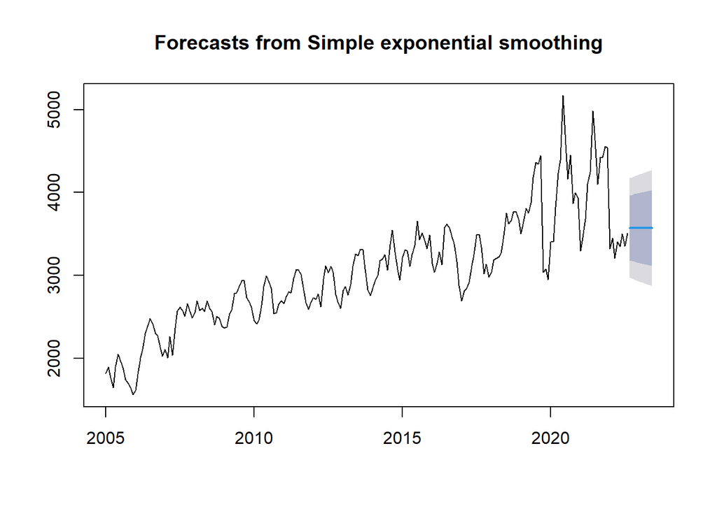

```r
plot(Demanda_electrico_SES)
```

Let´s see the forecast for next year´s gas use in electric sector

```r
Demanda_electrico_SES_forecast <- Demanda_electrico_SES$mean
Demanda_electrico_SES_forecast
```

```
##           Jan      Feb      Mar      Apr      May      Jun Jul Aug      Sep
## 2022                                                               3572.803
## 2023 3572.803 3572.803 3572.803 3572.803 3572.803 3572.803
##           Oct      Nov      Dec
## 2022 3572.803 3572.803 3572.803
## 2023
```

```r
head(Demanda_electrico_SES_forecast)
```

```
##           Jan      Feb Mar Apr May Jun Jul Aug      Sep      Oct      Nov
## 2022                                           3572.803 3572.803 3572.803
## 2023 3572.803 3572.803
##           Dec
## 2022 3572.803
## 2023
```

```r
tail(Demanda_electrico_SES_forecast)
```

```
##           Jan      Feb      Mar      Apr      May      Jun
## 2023 3572.803 3572.803 3572.803 3572.803 3572.803 3572.803
```

```r
typeof(Demanda_electrico_SES_forecast)
```

```
## [1] "double"
```

```r
dim(Demanda_electrico_SES_forecast)
```

Let´s plot the forecast generated by SES R model

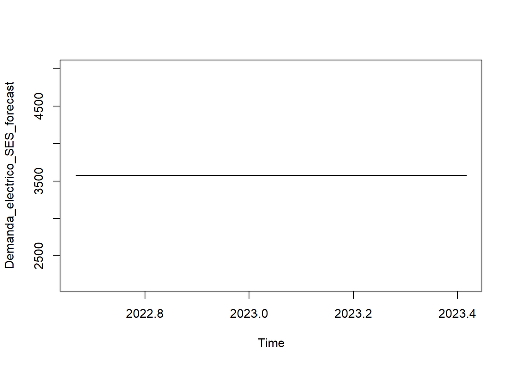

```r
plot(Demanda_electrico_SES_forecast)
```

Let´s try to find an ‘optimal alpha’

```r
# comparing our model
alpha <- seq(.01, .99, by = .01)
RMSE <- NA
for(i in seq_along(alpha)) {
  fit <- ses(Demanda_electrico_importado.ts, alpha = alpha[i],
             h = 100)
  RMSE[i] <- accuracy(fit)
}
```

[output not shown]

[output cut: 241 more lines]

[output not shown]

```r
# convert to a data frame and
# identify min alpha value
alpha.fit <- data_frame(alpha, RMSE)
```

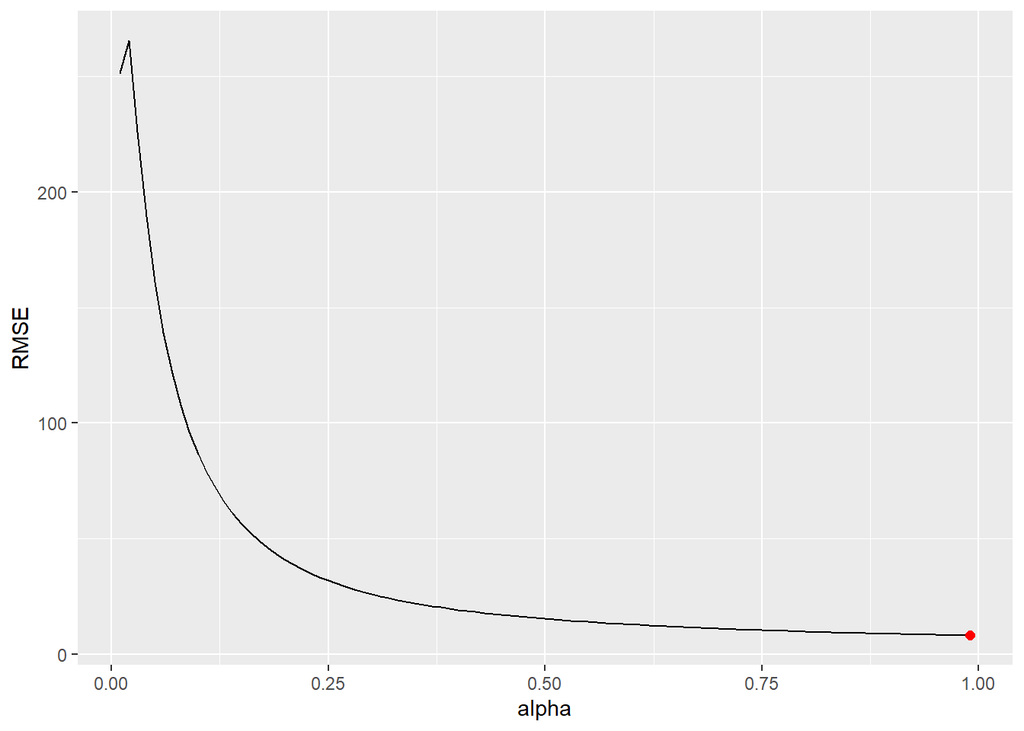

```r
alpha.min <- filter(alpha.fit,
                    RMSE == min(RMSE))

# plot RMSE vs. alpha
ggplot(alpha.fit, aes(alpha, RMSE)) +
  geom_line() +
  geom_point(data = alpha.min,
             aes(alpha, RMSE),
             size = 2, color = "red")
```

Let´s forecast next year´s gas use in electric sector USING THE FORECAST METHOD!!

```r
Demanda_electrico_forecast_con_datos_SES <-forecast(Demanda_electrico_SES)
head(Demanda_electrico_forecast_con_datos_SES)
```

```
## $model
## Simple exponential smoothing
##
## Call:
##  ses(y = Demanda_electrico_importado.ts, alpha = 0.2)
##
##   Smoothing parameters:
##     alpha = 0.2
##
##   Initial states:
##     l = 1838.6144
##
##   sigma:  306.11
##
##      AIC     AICc      BIC
## 3564.539 3564.597 3571.252
##
## $mean
##           Jan      Feb      Mar      Apr      May      Jun Jul Aug      Sep
## 2022                                                               3572.803
## 2023 3572.803 3572.803 3572.803 3572.803 3572.803 3572.803
##           Oct      Nov      Dec
## 2022 3572.803 3572.803 3572.803
## 2023
##
## $level
## [1] 80 95
##
## $x
##          Jan     Feb     Mar     Apr     May     Jun     Jul     Aug     Sep
## 2005 1819.58 1895.33 1765.86 1642.70 1895.54 2051.72 1962.05 1889.66 1739.10
## 2006 1610.45 1806.33 2006.88 2108.31 2298.90 2398.88 2480.62 2413.08 2298.49
## 2007 2108.85 2006.81 2259.02 2036.62 2361.78 2567.22 2618.43 2579.35 2506.83
## 2008 2548.33 2694.39 2575.71 2600.26 2562.91 2689.60 2598.57 2561.87 2404.84
## 2009 2364.05 2377.22 2536.70 2585.33 2782.32 2786.68 2866.00 2939.05 2943.11
## 2010 2452.18 2415.37 2460.19 2643.90 2864.36 2991.73 2917.25 2846.52 2540.74
## 2011 2662.78 2741.30 2802.85 2787.80 2964.66 3073.95 3065.73 3016.10 2822.19
## 2012 2732.35 2712.34 2772.88 2619.31 2955.93 3118.81 3035.23 3107.21 3037.41
## 2013 2823.51 2864.93 2761.36 2893.01 3112.88 3258.90 3238.75 3315.44 3305.59
## 2014 2837.06 2933.25 2997.46 3181.93 3201.21 3248.36 3064.23 3370.22 3547.07
```

[output cut: 38 more lines]

```
## May 2023 4023.516 4262.110
## Jun 2023 4030.294 4272.476
##
## $lower
##               80%      95%
## Sep 2022 3180.507 2972.838
## Oct 2022 3172.738 2960.957
## Nov 2022 3165.117 2949.301
## Dec 2022 3157.636 2937.860
## Jan 2023 3150.287 2926.621
## Feb 2023 3143.064 2915.575
## Mar 2023 3135.961 2904.711
## Apr 2023 3128.971 2894.020
## May 2023 3122.089 2883.496
## Jun 2023 3115.311 2873.130
```

```r
tail(Demanda_electrico_forecast_con_datos_SES)
```

```
## $upper
##               80%      95%
## Sep 2022 3965.098 4172.767
## Oct 2022 3972.867 4184.649
## Nov 2022 3980.488 4196.304
## Dec 2022 3987.970 4207.746
## Jan 2023 3995.318 4218.984
## Feb 2023 4002.541 4230.031
## Mar 2023 4009.645 4240.895
## Apr 2023 4016.635 4251.585
## May 2023 4023.516 4262.110
## Jun 2023 4030.294 4272.476
##
## $lower
##               80%      95%
## Sep 2022 3180.507 2972.838
## Oct 2022 3172.738 2960.957
## Nov 2022 3165.117 2949.301
## Dec 2022 3157.636 2937.860
## Jan 2023 3150.287 2926.621
## Feb 2023 3143.064 2915.575
## Mar 2023 3135.961 2904.711
## Apr 2023 3128.971 2894.020
## May 2023 3122.089 2883.496
## Jun 2023 3115.311 2873.130
##
## $fitted
##           Jan      Feb      Mar      Apr      May      Jun      Jul      Aug
## 2005 1838.614 1834.807 1846.912 1830.702 1793.101 1813.589 1861.215 1881.382
## 2006 1742.482 1716.075 1734.126 1788.677 1852.604 1941.863 2033.266 2122.737
## 2007 2166.385 2154.878 2125.265 2152.016 2128.937 2175.505 2253.848 2326.765
## 2008 2480.914 2494.397 2534.396 2542.659 2554.179 2555.925 2582.660 2585.842
## 2009 2497.989 2471.201 2452.405 2469.264 2492.477 2550.446 2597.693 2651.354
## 2010 2712.532 2660.462 2611.443 2581.193 2593.734 2647.859 2716.633 2756.757
## 2011 2686.173 2681.494 2693.455 2715.334 2729.827 2776.794 2836.225 2882.126
## 2012 2770.092 2762.544 2752.503 2756.579 2729.125 2774.486 2843.351 2881.727
## 2013 2813.615 2815.594 2825.461 2812.641 2828.715 2885.548 2960.218 3015.925
## 2014 2996.398 2964.531 2958.275 2966.112 3009.275 3047.662 3087.802 3083.087
## 2015 3149.750 3162.608 3192.172 3213.068 3192.412 3204.694 3235.459 3320.065
## 2016 3396.338 3345.695 3283.902 3257.273 3262.349 3235.935 3303.846 3365.947
```

[output cut: 75 more lines]

```
## 2008   -54.470887  -142.586710
## 2009   -72.231325  -121.565060
## 2010   -37.476415     4.808868
## 2011  -255.953792  -130.703034
## 2012  -230.670472  -263.606378
## 2013  -287.860127  -296.648101
## 2014  -161.318142  -261.574514
## 2015   -60.810100   117.451920
## 2016  -244.393005  -483.084404
## 2017   -67.046071  -205.426857
## 2018   255.977726   108.942181
## 2019  -799.705847  -769.294677
## 2020  -173.448408  -193.778726
## 2021   266.580352   194.794281
## 2022
```

```r
typeof(Demanda_electrico_forecast_con_datos_SES)
```

```
## [1] "list"
```

Let’s plot the forecast USING THE FORECAST METHOD NOT explicitely the SES method

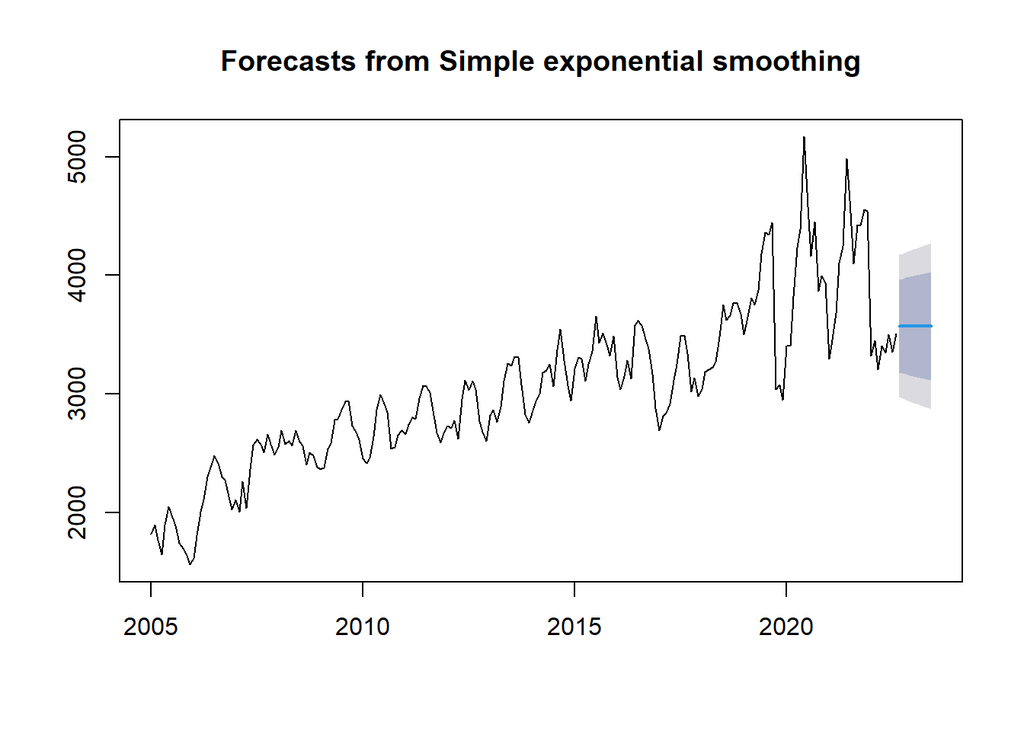

```r
plot(Demanda_electrico_forecast_con_datos_SES)
```

Let’s see the error metrics of the forecast USING THE FORECAST METHOD!!

```r
accuracy(Demanda_electrico_forecast_con_datos_SES)
```

```
##                    ME     RMSE      MAE       MPE     MAPE      MASE      ACF1
## Training set 40.90067 304.6626 226.7078 0.7911693 7.320259 0.8252315 0.6554327
```

```r
#plot(Demanda_electrico_importado.ts, col = "red", main = "Demanda electrico 'original'vs Holt-Winters ")
#lines(Demanda_electrico_forecast_con_datos_SES, col="blue")
#legend("bottomright", legend = c("Demanda electrico original", "Demanda_electrico_forecast_con_datos_SES"), col = c("red", "blue"), lty = 1)
```

### Double Exponential smoothing (DES) or Holt´s Methods

Source :https://docs.oracle.com/cd/E57185_01/CBPPU/classic_nonseasonal_forecasting_method_parameters.htm

FOR SERIRES WITH TREND BUT NO SEASONALITY

Double exponential smoothing has two parameters: alpha and beta.

The controlling smoothing factor for a particular level denoted by (a) alpha and the additional factor for smoothing and decay control of trend changes denoted by (b) or beta. The trends can change additionally if the trend is linear and manipulatively when the trend is exponential.

The next value $\hat{Y}_{t} :$ at time t is estimated as the ‘level of the series at time t-1’ plus a trend component:

$$\hat{Y}_{t} = l_{t-1} +
(h)T_{t-1}$$
Where: $\hat{Y}_{t} :$ Forecast for time t $l_{t-1} :$ Level at time t-1 $(h)T_{t} :$ Trend component

So, the first term of the sum is:

$$l_{t-1} = \alpha * y_{y} + (1-\alpha
)*(l_{t-2} +T_{t-2})$$

Where: $y_{y} :$ ‘Known’ value at time t $l_{t-2} :$ Level at time t-2 $\alpha :$ Smoothing factor $T_{t-1}:$ Trend factor at time t-2

And the second term of the sum is:

$$T_{t-1} = \beta * (l_{t-1} - l_{t-2}) +
(1-\beta )*(T_{t-2})$$

Where: $T_{t} Trend factor at time t $l_{t-2} :$ Level at time t-2 $\beta :$ Factor for smoothing and decay control of trend changes denoted $l_{t-1} :$ Level at time t-1 $l_{t-2} :$ Level at time t-2 $T_{t-2}:$ Trend factor at time t-2

### Replication of Double Exponential Smoothing or Holt´s method in R (https://www.geeksforgeeks.org/exponential-smoothing-in-r-programming/)

In R, to apply the Holt’s Method we are going to use the holt() function

```r
Demanda_electrico_Holt <- holt(Demanda_electrico_importado.ts)
head(Demanda_electrico_Holt)
```

```
## $model
## Holt's method
##
## Call:
##  holt(y = Demanda_electrico_importado.ts)
##
##   Smoothing parameters:
##     alpha = 0.9787
##     beta  = 1e-04
##
##   Initial states:
##     l = 1869.4409
##     b = 8.3885
##
##   sigma:  234.2284
##
##      AIC     AICc      BIC
## 3455.028 3455.319 3471.811
##
## $mean
##           Jan      Feb      Mar      Apr      May      Jun Jul Aug      Sep
## 2022                                                               3511.732
## 2023 3545.224 3553.597 3561.971 3570.344 3578.717 3587.090
##           Oct      Nov      Dec
## 2022 3520.105 3528.478 3536.851
## 2023
##
## $level
## [1] 80 95
##
## $x
##          Jan     Feb     Mar     Apr     May     Jun     Jul     Aug     Sep
## 2005 1819.58 1895.33 1765.86 1642.70 1895.54 2051.72 1962.05 1889.66 1739.10
## 2006 1610.45 1806.33 2006.88 2108.31 2298.90 2398.88 2480.62 2413.08 2298.49
## 2007 2108.85 2006.81 2259.02 2036.62 2361.78 2567.22 2618.43 2579.35 2506.83
## 2008 2548.33 2694.39 2575.71 2600.26 2562.91 2689.60 2598.57 2561.87 2404.84
## 2009 2364.05 2377.22 2536.70 2585.33 2782.32 2786.68 2866.00 2939.05 2943.11
## 2010 2452.18 2415.37 2460.19 2643.90 2864.36 2991.73 2917.25 2846.52 2540.74
## 2011 2662.78 2741.30 2802.85 2787.80 2964.66 3073.95 3065.73 3016.10 2822.19
## 2012 2732.35 2712.34 2772.88 2619.31 2955.93 3118.81 3035.23 3107.21 3037.41
```

[output cut: 40 more lines]

```
## May 2023 4462.587 4930.479
## Jun 2023 4518.592 5011.699
##
## $lower
##               80%      95%
## Sep 2022 3211.556 3052.653
## Oct 2022 3100.065 2877.709
## Nov 2022 3015.858 2744.493
## Dec 2022 2945.968 2633.173
## Jan 2023 2885.281 2535.929
## Feb 2023 2831.155 2448.717
## Mar 2023 2782.009 2369.122
## Apr 2023 2736.812 2295.568
## May 2023 2694.847 2226.954
## Jun 2023 2655.588 2162.481
```

```r
tail(Demanda_electrico_Holt)
```

```
## $upper
##               80%      95%
## Sep 2022 3811.908 3970.811
## Oct 2022 3940.145 4162.501
## Nov 2022 4041.099 4312.463
## Dec 2022 4127.735 4440.530
## Jan 2023 4205.167 4554.520
## Feb 2023 4276.040 4658.478
## Mar 2023 4341.932 4754.819
## Apr 2023 4403.875 4845.120
## May 2023 4462.587 4930.479
## Jun 2023 4518.592 5011.699
##
## $lower
##               80%      95%
## Sep 2022 3211.556 3052.653
## Oct 2022 3100.065 2877.709
## Nov 2022 3015.858 2744.493
## Dec 2022 2945.968 2633.173
## Jan 2023 2885.281 2535.929
## Feb 2023 2831.155 2448.717
## Mar 2023 2782.009 2369.122
## Apr 2023 2736.812 2295.568
## May 2023 2694.847 2226.954
## Jun 2023 2655.588 2162.481
##
## $fitted
##           Jan      Feb      Mar      Apr      May      Jun      Jul      Aug
## 2005 1877.829 1829.202 1902.312 1777.140 1653.924 1898.784 2056.867 1972.460
## 2006 1571.403 1617.970 1810.691 2011.094 2114.640 2303.396 2405.275 2487.451
## 2007 2036.918 2115.710 2017.508 2262.284 2049.805 2363.553 2571.319 2625.866
## 2008 2499.914 2555.726 2699.879 2586.780 2608.402 2572.302 2695.539 2609.060
## 2009 2394.619 2373.098 2385.530 2541.895 2592.822 2786.723 2795.117 2872.934
## 2010 2625.261 2464.260 2424.802 2467.831 2648.565 2868.201 2997.547 2927.397
## 2011 2697.826 2671.933 2748.237 2810.107 2796.692 2969.519 3080.172 3074.480
## 2012 2672.571 2739.481 2721.318 2780.188 2631.124 2957.439 3123.814 3045.545
## 2013 2613.018 2827.432 2872.538 2772.121 2898.844 3116.753 3264.317 3247.734
## 2014 2769.179 2844.009 2939.753 3004.640 3186.583 3209.326 3255.961 3076.723
## 2015 2951.987 3216.884 3316.870 3305.509 3122.365 3259.444 3364.843 3660.701
## 2016 3495.431 3159.024 3047.726 3156.970 3288.391 3142.045 3574.708 3621.953
```

[output cut: 75 more lines]

```
## 2008 -2.741206e+01 -1.080043e+02
## 2009 -6.751974e+01 -7.363776e+01
## 2010  9.487694e+01  2.840180e+01
## 2011 -9.124338e+01  6.372685e+01
## 2012 -9.916835e+01 -8.957076e+01
## 2013 -2.673636e+02 -8.044536e+01
## 2014 -2.254551e+02 -1.457283e+02
## 2015 -1.038214e+02  1.554655e+02
## 2016 -2.244843e+02 -3.007466e+02
## 2017  1.027303e+02 -1.579879e+02
## 2018  1.130116e-01 -1.042770e+02
## 2019  7.189132e-01 -1.378726e+02
## 2020  1.054970e+02 -6.121592e+01
## 2021  1.311864e+02 -2.416607e+01
## 2022
```

```r
typeof(Demanda_electrico_Holt)
```

```
## [1] "list"
```

Let´s see only the SMOTHED VALUES

```r
Smoothed_values_Demanda_electrico_Holt <- Demanda_electrico_SES$x
Smoothed_values_Demanda_electrico_Holt
```

```
##          Jan     Feb     Mar     Apr     May     Jun     Jul     Aug     Sep
## 2005 1819.58 1895.33 1765.86 1642.70 1895.54 2051.72 1962.05 1889.66 1739.10
## 2006 1610.45 1806.33 2006.88 2108.31 2298.90 2398.88 2480.62 2413.08 2298.49
## 2007 2108.85 2006.81 2259.02 2036.62 2361.78 2567.22 2618.43 2579.35 2506.83
## 2008 2548.33 2694.39 2575.71 2600.26 2562.91 2689.60 2598.57 2561.87 2404.84
## 2009 2364.05 2377.22 2536.70 2585.33 2782.32 2786.68 2866.00 2939.05 2943.11
## 2010 2452.18 2415.37 2460.19 2643.90 2864.36 2991.73 2917.25 2846.52 2540.74
## 2011 2662.78 2741.30 2802.85 2787.80 2964.66 3073.95 3065.73 3016.10 2822.19
## 2012 2732.35 2712.34 2772.88 2619.31 2955.93 3118.81 3035.23 3107.21 3037.41
## 2013 2823.51 2864.93 2761.36 2893.01 3112.88 3258.90 3238.75 3315.44 3305.59
## 2014 2837.06 2933.25 2997.46 3181.93 3201.21 3248.36 3064.23 3370.22 3547.07
## 2015 3214.04 3310.43 3296.65 3109.79 3253.82 3358.52 3658.49 3432.34 3514.52
## 2016 3143.12 3036.73 3150.76 3282.65 3130.28 3575.49 3614.35 3576.18 3465.07
## 2017 2690.93 2815.47 2838.20 2914.01 3119.05 3253.94 3491.19 3491.77 3339.67
## 2018 3041.46 3186.84 3203.37 3222.52 3270.33 3479.69 3751.09 3620.71 3664.34
```

[output cut: 23 more lines]

```r
head(Smoothed_values_Demanda_electrico_Holt)
```

```
##          Jan     Feb     Mar     Apr     May     Jun
## 2005 1819.58 1895.33 1765.86 1642.70 1895.54 2051.72
```

```r
tail(Smoothed_values_Demanda_electrico_Holt)
```

```
##          Mar     Apr     May     Jun     Jul     Aug
## 2022 3206.96 3403.44 3350.03 3498.70 3350.97 3506.42
```

```r
typeof(Smoothed_values_Demanda_electrico_Holt)
```

```
## [1] "double"
```

```r
dim(Smoothed_values_Demanda_electrico_Holt)
```

SMOOTHED VALUS ARE EQUAL THAN ORIGINAL ONES

```r
plot(Demanda_electrico_importado.ts, col = "red", main = "Demanda electrico 'original' ")
lines(Smoothed_values_Demanda_electrico_Holt , col='purple')
```

[output not shown]

LEt´s plot the forecast

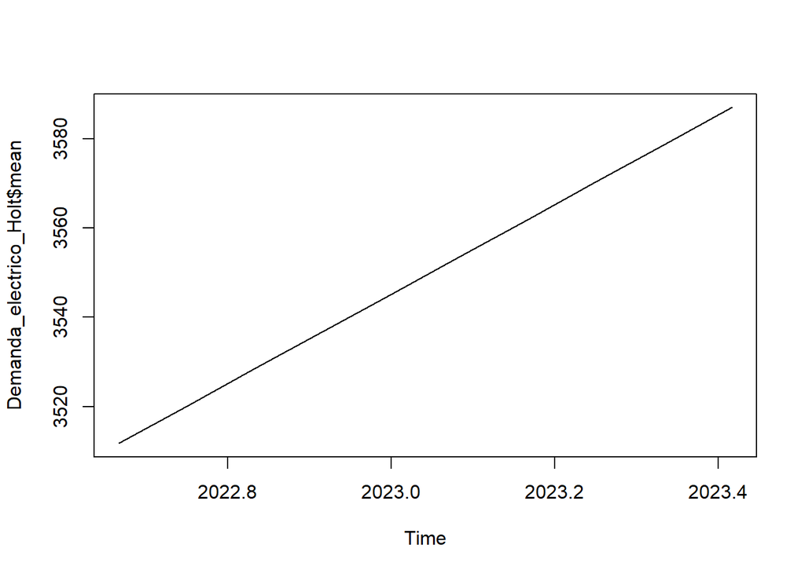

```r
plot(Demanda_electrico_Holt$mean)
```

Let´s see the forecast for next year´s gas use in electric sector

```r
Demanda_electrico_Holt_forecast <- Demanda_electrico_Holt$mean
Demanda_electrico_Holt_forecast
```

```
##           Jan      Feb      Mar      Apr      May      Jun Jul Aug      Sep
## 2022                                                               3511.732
## 2023 3545.224 3553.597 3561.971 3570.344 3578.717 3587.090
##           Oct      Nov      Dec
## 2022 3520.105 3528.478 3536.851
## 2023
```

```r
head(Demanda_electrico_Holt_forecast)
```

```
##           Jan      Feb Mar Apr May Jun Jul Aug      Sep      Oct      Nov
## 2022                                           3511.732 3520.105 3528.478
## 2023 3545.224 3553.597
##           Dec
## 2022 3536.851
## 2023
```

```r
tail(Demanda_electrico_Holt_forecast)
```

```
##           Jan      Feb      Mar      Apr      May      Jun
## 2023 3545.224 3553.597 3561.971 3570.344 3578.717 3587.090
```

```r
typeof(Demanda_electrico_Holt_forecast)
```

```
## [1] "double"
```

```r
dim(Demanda_electrico_Holt_forecast)
```

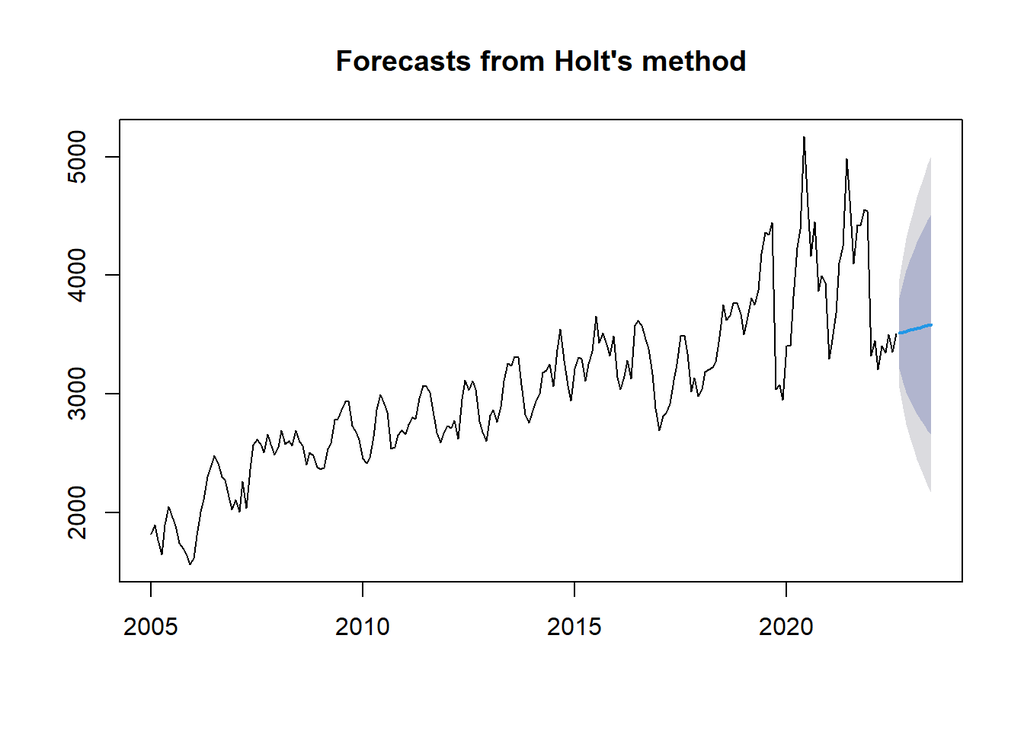

```r
plot(Demanda_electrico_Holt)
```

## Seasonal Methods

### Holt-Winters

Source: https://docs.oracle.com/cd/E57185_01/CBPPU/holt-winters_additive.htm

#### Holt-Winters additive

Is an extension of Holt’s exponential smoothing that captures seasonality. This method produces exponentially smoothed values for the level of the forecast, the trend of the forecast, and the seasonal adjustment to the forecast. This seasonal additive method adds the seasonality factor to the trended forecast, producing the Holt-Winters’ additive forecast.

This method is best for data with trend and seasonality that does not increase over time. It results in a curved forecast that shows the seasonal changes in the data.

https://otexts.com/fpp2/holt-winters.html

$$\begin{align*}
\hat{y}_{t+h|t} &= \ell_{t} + hb_{t} + s_{t+h-m(k+1)} \\
\ell_{t} &= \alpha(y_{t} - s_{t-m}) + (1 - \alpha)(\ell_{t-1} +
b_{t-1})\\
b_{t} &= \beta^*(\ell_{t} - \ell_{t-1}) + (1 - \beta^*)b_{t-1}\\
s_{t} &= \gamma (y_{t}-\ell_{t-1}-b_{t-1}) + (1-\gamma)s_{t-m},
\end{align*}$$

The equation for the seasonal component is often expressed as

$$s_{t} = \gamma^* (y_{t}-\ell_{t})+
(1-\gamma^*)s_{t-m}$$
If we substitute ℓt from the smoothing equation for the level of the component form above, we get

$$s_{t} = \gamma^*(1-\alpha)
(y_{t}-\ell_{t-1}-b_{t-1})+ [1-\gamma^*(1-\alpha)]s_{t-m}$$

#### Holt-Winters multiplicative

Is similar to the Holt-Winters’ additive method. Holt-Winters’ Multiplicative method also calculates exponentially smoothed values for level, trend, and seasonal adjustment to the forecast. This seasonal multiplicative method multiplies the trended forecast by the seasonality, producing the Holt-Winters’ multiplicative forecast.

This method is best for data with trend and with seasonality that increases over time. It results in a curved forecast that reproduces the seasonal changes in the data.

$$\begin{align*}
\hat{y}_{t+h|t} &= (\ell_{t} + hb_{t})s_{t+h-m(k+1)} \\
\ell_{t} &= \alpha \frac{y_{t}}{s_{t-m}} + (1 - \alpha)(\ell_{t-1}
+ b_{t-1})\\
b_{t} &= \beta^*(\ell_{t}-\ell_{t-1}) + (1 -
\beta^*)b_{t-1} \\
s_{t} &= \gamma \frac{y_{t}}{(\ell_{t-1} + b_{t-1})} + (1 -
\gamma)s_{t-m}
\end{align*}$$

## Classic Seasonal Forecasting Method Parameters

Source: https://docs.oracle.com/cd/E57185_01/CBPPU/classic_seasonal_forecasting_method_parameters.htm

The seasonal forecast methods use the following parameters:

alpha (α) — Smoothing parameter for the level component of the forecast. The value of alpha can be any number between 0 and 1, not inclusive.

beta (β) — Smoothing parameter for the trend component of the forecast. The value of beta can be any number between 0 and 1, not inclusive.

gamma (γ) — Smoothing parameter for the seasonality component of the forecast. The value of gamma can be any number between 0 and 1, not inclusive.

phi (Φ) — Damping parameter; any number between 0 and 1, not inclusive.

### Replication of Holt Winter´s method in R

Then we are able to apply the HoltWinters method

```r
Demanda_electrico_HW <- HoltWinters(Demanda_electrico_importado.ts)
head(Demanda_electrico_HW)
```

```
## $fitted
##              xhat    level     trend      season
## Jan 2006 1451.937 1695.588 34.620395 -278.271562
## Feb 2006 1777.552 1867.766 35.594272 -125.807812
## Mar 2006 1993.729 1928.333 35.771080   29.625104
## Apr 2006 2095.032 1975.516 35.851874   83.664271
## May 2006 2288.768 2022.890 35.933449  229.943854
## Jun 2006 2393.934 2067.617 35.995700  290.321354
## Jul 2006 2344.165 2107.905 36.026090  200.234271
## Aug 2006 2439.477 2262.346 36.864445  140.266354
## Sep 2006 2296.378 2276.303 36.702268  -16.627813
## Oct 2006 2262.303 2314.839 36.715245  -89.250729
## Nov 2006 2225.985 2361.626 36.786556 -172.427812
## Dec 2006 2063.499 2318.944 36.223935 -291.669479
## Jan 2007 2099.116 2322.610 35.993426 -259.487430
## Feb 2007 2280.706 2367.051 36.053232 -122.397559
## Mar 2007 2230.972 2165.418 34.370462   31.183473
## Apr 2007 2343.909 2224.128 34.542786   85.237683
## May 2007 2255.806 1992.007 32.654857  231.144553
## Jun 2007 2440.839 2116.625 33.305940  290.907504
## Jul 2007 2510.091 2259.604 34.082404  216.404451
## Aug 2007 2559.589 2387.703 34.748018  137.138296
## Sep 2007 2458.091 2439.599 34.869426  -16.377518
## Oct 2007 2464.058 2516.764 35.168869  -87.875288
## Nov 2007 2572.652 2719.576 36.355748 -183.279632
## Dec 2007 2500.819 2760.547 36.388421 -296.115535
## Jan 2008 2565.001 2787.017 36.318200 -258.333885
## Feb 2008 2690.229 2808.868 36.215777 -154.854803
## Mar 2008 2919.443 2848.695 36.241343   34.507263
## Apr 2008 2669.598 2586.646 34.129505   48.823336
## May 2008 2838.010 2560.603 33.703502  243.702626
## Jun 2008 2693.474 2355.577 32.013338  305.883930
## Jul 2008 2645.461 2384.228 31.989538  229.242806
## Aug 2008 2546.708 2375.526 31.701450  139.480005
## Sep 2008 2441.578 2420.385 31.794604  -10.601866
## Oct 2008 2386.885 2420.299 31.568891  -64.982792
## Nov 2008 2402.946 2553.309 32.287074 -182.649434
## Dec 2008 2390.314 2655.005 32.778479 -297.469948
## Jan 2009 2454.665 2682.235 32.739197 -260.309416
## Feb 2009 2514.160 2636.339 32.182474 -154.361694
```

[output cut: 205 more lines]

```
## 0.8677962
##
## $beta
##        beta
## 0.007079803
##
## $gamma
##     gamma
## 0.8963586
##
## $coefficients
##          a          b         s1         s2         s3         s4         s5
## 3351.38775   11.30299  183.82586 -215.74643 -185.17437 -291.49823 -488.95930
##         s6         s7         s8         s9        s10        s11        s12
## -244.21448 -140.19855   16.82936   92.07814  415.07341  257.12173  151.11721
```

```r
tail(Demanda_electrico_HW)
```

```
## $beta
##        beta
## 0.007079803
##
## $gamma
##     gamma
## 0.8963586
##
## $coefficients
##          a          b         s1         s2         s3         s4         s5
## 3351.38775   11.30299  183.82586 -215.74643 -185.17437 -291.49823 -488.95930
##         s6         s7         s8         s9        s10        s11        s12
## -244.21448 -140.19855   16.82936   92.07814  415.07341  257.12173  151.11721
##
## $seasonal
## [1] "additive"
##
## $SSE
## [1] 9403621
##
## $call
## HoltWinters(x = Demanda_electrico_importado.ts)
```

```r
typeof(Demanda_electrico_HW)
```

```
## [1] "list"
```

Let´s see only the SMOTHED VALUES

```r
Smoothed_values_Demanda_electrico_HW <- Demanda_electrico_HW$x
Smoothed_values_Demanda_electrico_HW
```

```
##          Jan     Feb     Mar     Apr     May     Jun     Jul     Aug     Sep
## 2005 1819.58 1895.33 1765.86 1642.70 1895.54 2051.72 1962.05 1889.66 1739.10
## 2006 1610.45 1806.33 2006.88 2108.31 2298.90 2398.88 2480.62 2413.08 2298.49
## 2007 2108.85 2006.81 2259.02 2036.62 2361.78 2567.22 2618.43 2579.35 2506.83
## 2008 2548.33 2694.39 2575.71 2600.26 2562.91 2689.60 2598.57 2561.87 2404.84
## 2009 2364.05 2377.22 2536.70 2585.33 2782.32 2786.68 2866.00 2939.05 2943.11
## 2010 2452.18 2415.37 2460.19 2643.90 2864.36 2991.73 2917.25 2846.52 2540.74
## 2011 2662.78 2741.30 2802.85 2787.80 2964.66 3073.95 3065.73 3016.10 2822.19
## 2012 2732.35 2712.34 2772.88 2619.31 2955.93 3118.81 3035.23 3107.21 3037.41
## 2013 2823.51 2864.93 2761.36 2893.01 3112.88 3258.90 3238.75 3315.44 3305.59
## 2014 2837.06 2933.25 2997.46 3181.93 3201.21 3248.36 3064.23 3370.22 3547.07
## 2015 3214.04 3310.43 3296.65 3109.79 3253.82 3358.52 3658.49 3432.34 3514.52
## 2016 3143.12 3036.73 3150.76 3282.65 3130.28 3575.49 3614.35 3576.18 3465.07
## 2017 2690.93 2815.47 2838.20 2914.01 3119.05 3253.94 3491.19 3491.77 3339.67
## 2018 3041.46 3186.84 3203.37 3222.52 3270.33 3479.69 3751.09 3620.71 3664.34
```

[output cut: 23 more lines]

```r
head(Smoothed_values_Demanda_electrico_HW)
```

```
##          Jan     Feb     Mar     Apr     May     Jun
## 2005 1819.58 1895.33 1765.86 1642.70 1895.54 2051.72
```

```r
tail(Smoothed_values_Demanda_electrico_HW)
```

```
##          Mar     Apr     May     Jun     Jul     Aug
## 2022 3206.96 3403.44 3350.03 3498.70 3350.97 3506.42
```

```r
typeof(Smoothed_values_Demanda_electrico_HW)
```

```
## [1] "double"
```

```r
dim(Smoothed_values_Demanda_electrico_HW)
```

SMOOTHED VALUS ARE EQUAL THAN ORIGINAL ONES

```r
plot(Demanda_electrico_importado.ts, col = "red", main = "Demanda electrico 'original' ")
lines(Smoothed_values_Demanda_electrico_HW , col='purple')
```

[output not shown]

```r
#plot(Demanda_electrico_HW$mean)
```

```r
Demanda_electrico_HW_forecast <- Demanda_electrico_HW$mean
Demanda_electrico_HW_forecast
```

```r
head(Demanda_electrico_HW_forecast)
```

```r
tail(Demanda_electrico_HW_forecast)
```

```r
typeof(Demanda_electrico_HW_forecast)
```

```
## [1] "NULL"
```

```r
dim(Demanda_electrico_HW_forecast)
```

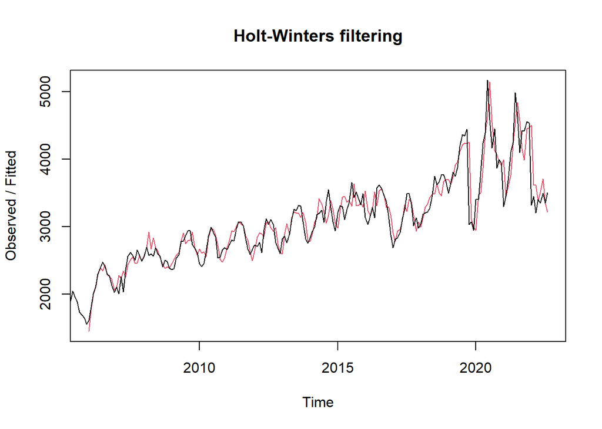

```r
plot(Demanda_electrico_HW)
```